# francisco brady

[Home](https://franciscothebrady.github.io/index.html)

[Resume](https://franciscothebrady.github.io/resume.html)

[Research and Other Work](https://franciscothebrady.github.io/research.html)

[Resources](https://franciscothebrady.github.io/resources.html)

[Connect](https://franciscothebrady.github.io/connect.html)

#### Hello!

I am currently a Data & Policy analyst at [Poverty Solutions](https://poverty.umich.edu/) at the University of Michigan.

**None of my opinions represent the views of the University of Michigan or Poverty Solutions**

I am currently a student in the Master of Public Policy program at the [Ford School of Public Policy](https://fordschool.umich.edu/)

**I’m pretty sure I can say whatever I want when I’m a student**

I am currently a Research Analyst at the UChicago Urban Lab’s [Inclusive Economy Lab](https://urbanlabs.uchicago.edu/labs/inclusiveeconomy)

**None of my spicier takes represent the sum total of the views of the University of Chicago or Urban Labs**

I am currently a research assistant in the Real Estate Finance section at the [Federal Reserve](https://www.federalreserve.gov/econres/rsref-staff.htm).

**None of my opinions represent the views of the federal reserve or any of the reserve banks**

Research Interests:  
- Public Policy and Economic Research, especially as it pertains to:  
– inequality  
– housing stability and homelessness  
– urban economics  
– basic income pilots  
– open source programming  
– other cool things

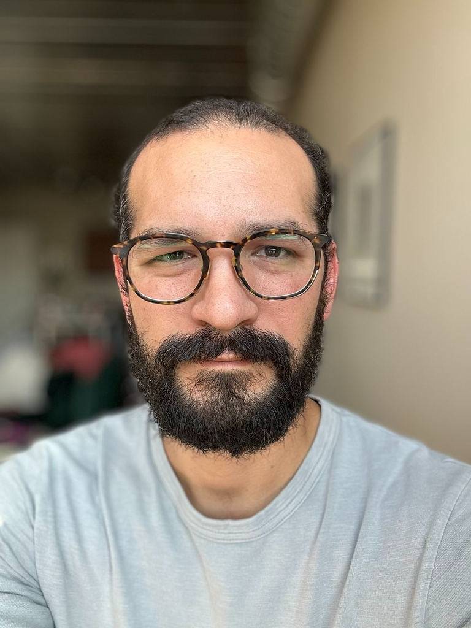